```python
# 1. Import necessary libraries
import pandas as pd
import numpy as np
import matplotlib.pyplot as plt
import seaborn as sns

# Machine Learning Libraries
from sklearn.model_selection import train_test_split
from sklearn.preprocessing import LabelEncoder, StandardScaler, minmax_scale
from sklearn.ensemble import RandomForestClassifier
from sklearn.metrics import classification_report, confusion_matrix, accuracy_score
from sklearn.impute import SimpleImputer
%matplotlib inline
from ydata_profiling import ProfileReport
from sklearn.linear_model import LogisticRegression

# Ignore warnings for cleaner output
import warnings
warnings.filterwarnings('ignore')
```

# Data Cleaning

```python
#loading the dataset
df = pd.read_csv("Train_data_b9ac66e0e2fff2f1c135c159f8e823e0.csv")

#displaying the first five rows of the dataset
df.head()
```

|  | Customer Id | YearOfObservation | Insured_Period | Residential | Building_Painted | Building_Fenced | Garden | Settlement | Building Dimension | Building_Type | Date_of_Occupancy | NumberOfWindows | Geo_Code | Claim |
| --- | --- | --- | --- | --- | --- | --- | --- | --- | --- | --- | --- | --- | --- | --- |
| 0 | H14663 | 2013 | 1.0 | 0 | N | V | V | U | 290.0 | 1 | 1960.0 | . | 1053 | 0 |
| 1 | H2037 | 2015 | 1.0 | 0 | V | N | O | R | 490.0 | 1 | 1850.0 | 4 | 1053 | 0 |
| 2 | H3802 | 2014 | 1.0 | 0 | N | V | V | U | 595.0 | 1 | 1960.0 | . | 1053 | 0 |
| 3 | H3834 | 2013 | 1.0 | 0 | V | V | V | U | 2840.0 | 1 | 1960.0 | . | 1053 | 0 |
| 4 | H5053 | 2014 | 1.0 | 0 | V | N | O | R | 680.0 | 1 | 1800.0 | 3 | 1053 | 0 |

```python
df.tail()
```

|  | Customer Id | YearOfObservation | Insured_Period | Residential | Building_Painted | Building_Fenced | Garden | Settlement | Building Dimension | Building_Type | Date_of_Occupancy | NumberOfWindows | Geo_Code | Claim |
| --- | --- | --- | --- | --- | --- | --- | --- | --- | --- | --- | --- | --- | --- | --- |
| 7155 | H5290 | 2012 | 1.000000 | 1 | V | V | V | U | NaN | 1 | 2001.0 | . | NaN | 0 |
| 7156 | H5926 | 2013 | 1.000000 | 0 | V | V | V | U | NaN | 2 | 1980.0 | . | NaN | 1 |
| 7157 | H6204 | 2016 | 0.038251 | 0 | V | V | V | U | NaN | 1 | 1992.0 | . | NaN | 0 |
| 7158 | H6537 | 2013 | 1.000000 | 0 | V | V | V | U | NaN | 1 | 1972.0 | . | NaN | 0 |
| 7159 | H7470 | 2014 | 1.000000 | 0 | V | V | V | U | NaN | 1 | 2004.0 | . | NaN | 0 |

```python
df.info()
```

```
<class 'pandas.core.frame.DataFrame'>
RangeIndex: 7160 entries, 0 to 7159
Data columns (total 14 columns):
 #   Column              Non-Null Count  Dtype
---  ------              --------------  -----
 0   Customer Id         7160 non-null   object
 1   YearOfObservation   7160 non-null   int64
 2   Insured_Period      7160 non-null   float64
 3   Residential         7160 non-null   int64
 4   Building_Painted    7160 non-null   object
 5   Building_Fenced     7160 non-null   object
 6   Garden              7153 non-null   object
 7   Settlement          7160 non-null   object
 8   Building Dimension  7054 non-null   float64
 9   Building_Type       7160 non-null   int64
 10  Date_of_Occupancy   6652 non-null   float64
 11  NumberOfWindows     7160 non-null   object
 12  Geo_Code            7058 non-null   object
 13  Claim               7160 non-null   int64
dtypes: float64(3), int64(4), object(7)
memory usage: 783.3+ KB
```

```python
df.describe()
```

|  | YearOfObservation | Insured_Period | Residential | Building Dimension | Building_Type | Date_of_Occupancy | Claim |
| --- | --- | --- | --- | --- | --- | --- | --- |
| count | 7160.000000 | 7160.000000 | 7160.000000 | 7054.000000 | 7160.000000 | 6652.000000 | 7160.000000 |
| mean | 2013.669553 | 0.909758 | 0.305447 | 1883.727530 | 2.186034 | 1964.456404 | 0.228212 |
| std | 1.383769 | 0.239756 | 0.460629 | 2278.157745 | 0.940632 | 36.002014 | 0.419709 |
| min | 2012.000000 | 0.000000 | 0.000000 | 1.000000 | 1.000000 | 1545.000000 | 0.000000 |
| 25% | 2012.000000 | 0.997268 | 0.000000 | 528.000000 | 2.000000 | 1960.000000 | 0.000000 |
| 50% | 2013.000000 | 1.000000 | 0.000000 | 1083.000000 | 2.000000 | 1970.000000 | 0.000000 |
| 75% | 2015.000000 | 1.000000 | 1.000000 | 2289.750000 | 3.000000 | 1980.000000 | 0.000000 |
| max | 2016.000000 | 1.000000 | 1.000000 | 20940.000000 | 4.000000 | 2016.000000 | 1.000000 |

```python
df.isnull().sum()
```

```
Customer Id             0
YearOfObservation       0
Insured_Period          0
Residential             0
Building_Painted        0
Building_Fenced         0
Garden                  7
Settlement              0
Building Dimension    106
Building_Type           0
Date_of_Occupancy     508
NumberOfWindows         0
Geo_Code              102
Claim                   0
dtype: int64
```

```python
df['Geo_Code'] = pd.to_numeric(df['Geo_Code'], errors='coerce') #converting the column to numeric
df['Geo_Code'].fillna(df['Geo_Code'].median(), inplace=True) #filling NaN values with median
df['Geo_Code'].value_counts() #checking the value counts after cleaning
```

```
Geo_Code
57463.0    198
6088.0     143
33063.0    137
6083.0     113
13206.0     98
          ...
95539.0      1
95426.0      1
95394.0      1
95252.0      1
4073.0       1
Name: count, Length: 1298, dtype: int64
```

The number_of_windows feature contained missing values represented by a dot (.). These values were first converted to NaN to enable numerical processing. The column was then cast to a numeric data type. Missing values were imputed using the median to reduce the influence of outliers and preserve dataset size.

```python
df['NumberOfWindows'].value_counts()
df['NumberOfWindows'] = df['NumberOfWindows'].replace('.', np.nan) #replacing   '.' with NaN
df['NumberOfWindows'] = pd.to_numeric(df['NumberOfWindows'], errors='coerce') #converting the column to numeric
df['NumberOfWindows'].fillna(df['NumberOfWindows'].median(), inplace=True) #filling NaN values with median
df['NumberOfWindows'].value_counts() #checking the value counts after cleaning
```

```
NumberOfWindows
4.0    4557
3.0     844
5.0     639
2.0     363
6.0     306
7.0     211
8.0     116
1.0      75
9.0      49
Name: count, dtype: int64
```

```python
df.drop(columns=["Customer Id"], inplace=True) #dropping the Customer Id column as it is not useful for prediction
df.isnull().sum()/df.shape[0] * 100  #checking the percentage of missing values in each column
```

```
YearOfObservation     0.000000
Insured_Period        0.000000
Residential           0.000000
Building_Painted      0.000000
Building_Fenced       0.000000
Garden                0.097765
Settlement            0.000000
Building Dimension    1.480447
Building_Type         0.000000
Date_of_Occupancy     7.094972
NumberOfWindows       0.000000
Geo_Code              0.000000
Claim                 0.000000
dtype: float64
```

```python
cat_cols = df.select_dtypes(include="object").columns

for col in cat_cols:
    df[col].fillna(df[col].mode()[0], inplace=True)   #filling missing values in categorical columns with mode
df.isnull().sum()  #checking if there are any missing values left
```

```
YearOfObservation       0
Insured_Period          0
Residential             0
Building_Painted        0
Building_Fenced         0
Garden                  0
Settlement              0
Building Dimension    106
Building_Type           0
Date_of_Occupancy     508
NumberOfWindows         0
Geo_Code                0
Claim                   0
dtype: int64
```

```python
num_cols = df.select_dtypes(include=["int64", "float64"]).columns

for col in num_cols:
    df[col].fillna(df[col].median(), inplace=True) #filling missing values in numerical columns with median
df.isnull().sum()  #checking if there are any missing values left
```

```
YearOfObservation     0
Insured_Period        0
Residential           0
Building_Painted      0
Building_Fenced       0
Garden                0
Settlement            0
Building Dimension    0
Building_Type         0
Date_of_Occupancy     0
NumberOfWindows       0
Geo_Code              0
Claim                 0
dtype: int64
```

```python
df.drop_duplicates(inplace=True)
df.duplicated().sum()  #checking if there are any duplicates left
```

```
np.int64(0)
```

#### Binary categorical variables were encoded using domain-specific mapping, where “N” was mapped to 1 and “V” to 0, in accordance with the dataset’s coding scheme. This transformation allowed the variables to be incorporated into numerical analysis and machine learning models.

```python
df['Building_Painted'].value_counts() #checking value counts of Building_Painted column
df['Building_Fenced'].value_counts() #checking value counts of Building_Fenced column

mapping = {'V': 0, 'N': 1}

df['Building_Painted'] = df['Building_Painted'].map(mapping) #mapping the values to 0 and 1
df['Building_Fenced'] = df['Building_Fenced'].map(mapping)
df.head()
```

|  | YearOfObservation | Insured_Period | Residential | Building_Painted | Building_Fenced | Garden | Settlement | Building Dimension | Building_Type | Date_of_Occupancy | NumberOfWindows | Geo_Code | Claim |
| --- | --- | --- | --- | --- | --- | --- | --- | --- | --- | --- | --- | --- | --- |
| 0 | 2013 | 1.0 | 0 | 1 | 0 | V | U | 290.0 | 1 | 1960.0 | 4.0 | 1053.0 | 0 |
| 1 | 2015 | 1.0 | 0 | 0 | 1 | O | R | 490.0 | 1 | 1850.0 | 4.0 | 1053.0 | 0 |
| 2 | 2014 | 1.0 | 0 | 1 | 0 | V | U | 595.0 | 1 | 1960.0 | 4.0 | 1053.0 | 0 |
| 3 | 2013 | 1.0 | 0 | 0 | 0 | V | U | 2840.0 | 1 | 1960.0 | 4.0 | 1053.0 | 0 |
| 4 | 2014 | 1.0 | 0 | 0 | 1 | O | R | 680.0 | 1 | 1800.0 | 3.0 | 1053.0 | 0 |

#### Categorical features with binary values were encoded using domain-informed binary mapping. For the Garden variable, “V” (has garden) was encoded as 1 and “O” (no garden) as 0. For the Settlement variable, “U” (urban) was encoded as 1 and “R” (rural) as 0. This ensured compatibility with numerical analysis and machine learning algorithms while preserving semantic meaning.

```python
df['Garden'].value_counts() #checking value counts of Garden column
df['Settlement'].value_counts() #checking value counts of Settlement column

garden_mapping = {'V': 1, 'O': 0}
settlement_mapping = {'U': 1, 'R': 0}

df['Garden'] = df['Garden'].map(garden_mapping)
df['Settlement'] = df['Settlement'].map(settlement_mapping)
df.head()
```

|  | YearOfObservation | Insured_Period | Residential | Building_Painted | Building_Fenced | Garden | Settlement | Building Dimension | Building_Type | Date_of_Occupancy | NumberOfWindows | Geo_Code | Claim |
| --- | --- | --- | --- | --- | --- | --- | --- | --- | --- | --- | --- | --- | --- |
| 0 | 2013 | 1.0 | 0 | 1 | 0 | 1 | 1 | 290.0 | 1 | 1960.0 | 4.0 | 1053.0 | 0 |
| 1 | 2015 | 1.0 | 0 | 0 | 1 | 0 | 0 | 490.0 | 1 | 1850.0 | 4.0 | 1053.0 | 0 |
| 2 | 2014 | 1.0 | 0 | 1 | 0 | 1 | 1 | 595.0 | 1 | 1960.0 | 4.0 | 1053.0 | 0 |
| 3 | 2013 | 1.0 | 0 | 0 | 0 | 1 | 1 | 2840.0 | 1 | 1960.0 | 4.0 | 1053.0 | 0 |
| 4 | 2014 | 1.0 | 0 | 0 | 1 | 0 | 0 | 680.0 | 1 | 1800.0 | 3.0 | 1053.0 | 0 |

```python
df['Insured_Period'].describe()
```

```
count    7148.000000
mean        0.909673
std         0.239887
min         0.000000
25%         0.997268
50%         1.000000
75%         1.000000
max         1.000000
Name: Insured_Period, dtype: float64
```

# Moving to Visualisation

```python
#df.to_csv('cleaned_Train_data_2026.csv', index=False)
# Exporting the cleaned dataset to a new CSV file
```

Building Dimension variables with high cardinality were examined individually. Numeric measurement variables were retained, identifier-like features were removed, and high-cardinality categorical features were either frequency-encoded or excluded to prevent dimensionality inflation and overfitting.

```python
df['Building_Condition_Score'] = (
    df['Building_Painted'] +
    df['Building_Fenced'] +
    df['Garden']
)

df.drop(
    columns=['Building_Painted', 'Building_Fenced', 'Garden'],
    inplace=True
)
```

```python
df.profile_report()
```

[output not shown]

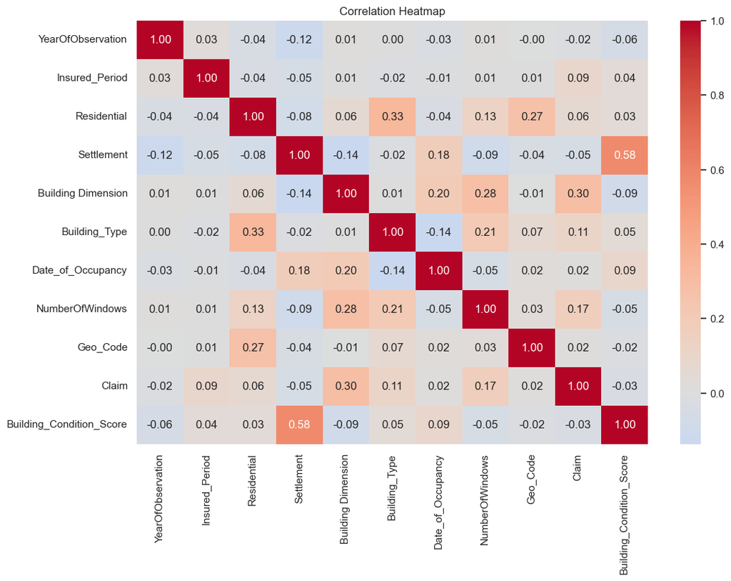

```python
corr_matrix = df.corr(method='pearson')
import matplotlib.pyplot as plt
import seaborn as sns

plt.figure(figsize=(12, 8)) #setting the figure size
sns.heatmap(
    corr_matrix,
    annot=True,
    fmt='.2f',
    cmap='coolwarm',
    center=0
)
plt.title('Correlation Heatmap') #title for the heatmap
plt.show()
```

```python
corr_target = corr_matrix['Claim'].sort_values(ascending=False)
corr_target
```

```
Claim                       1.000000
Building Dimension          0.295158
NumberOfWindows             0.172265
Building_Type               0.112416
Insured_Period              0.088742
Residential                 0.064106
Date_of_Occupancy           0.017834
Geo_Code                    0.016896
YearOfObservation          -0.016731
Building_Condition_Score   -0.030865
Settlement                 -0.052306
Name: Claim, dtype: float64
```

```python
corr_matrix
```

|  | YearOfObservation | Insured_Period | Residential | Settlement | Building Dimension | Building_Type | Date_of_Occupancy | NumberOfWindows | Geo_Code | Claim | Building_Condition_Score |
| --- | --- | --- | --- | --- | --- | --- | --- | --- | --- | --- | --- |
| YearOfObservation | 1.000000 | 0.025786 | -0.040021 | -0.119482 | 0.010726 | 0.004896 | -0.029747 | 0.012861 | -0.002019 | -0.016731 | -0.056549 |
| Insured_Period | 0.025786 | 1.000000 | -0.037283 | -0.046598 | 0.008600 | -0.017638 | -0.010569 | 0.006728 | 0.005692 | 0.088742 | 0.037457 |
| Residential | -0.040021 | -0.037283 | 1.000000 | -0.082879 | 0.057127 | 0.334240 | -0.037026 | 0.132119 | 0.268431 | 0.064106 | 0.033180 |
| Settlement | -0.119482 | -0.046598 | -0.082879 | 1.000000 | -0.136451 | -0.019873 | 0.175632 | -0.094842 | -0.042629 | -0.052306 | 0.575562 |
| Building Dimension | 0.010726 | 0.008600 | 0.057127 | -0.136451 | 1.000000 | 0.009266 | 0.196331 | 0.281100 | -0.007116 | 0.295158 | -0.089035 |
| Building_Type | 0.004896 | -0.017638 | 0.334240 | -0.019873 | 0.009266 | 1.000000 | -0.136827 | 0.210569 | 0.068653 | 0.112416 | 0.049149 |
| Date_of_Occupancy | -0.029747 | -0.010569 | -0.037026 | 0.175632 | 0.196331 | -0.136827 | 1.000000 | -0.050787 | 0.021543 | 0.017834 | 0.093946 |
| NumberOfWindows | 0.012861 | 0.006728 | 0.132119 | -0.094842 | 0.281100 | 0.210569 | -0.050787 | 1.000000 | 0.026779 | 0.172265 | -0.051071 |
| Geo_Code | -0.002019 | 0.005692 | 0.268431 | -0.042629 | -0.007116 | 0.068653 | 0.021543 | 0.026779 | 1.000000 | 0.016896 | -0.019895 |
| Claim | -0.016731 | 0.088742 | 0.064106 | -0.052306 | 0.295158 | 0.112416 | 0.017834 | 0.172265 | 0.016896 | 1.000000 | -0.030865 |
| Building_Condition_Score | -0.056549 | 0.037457 | 0.033180 | 0.575562 | -0.089035 | 0.049149 | 0.093946 | -0.051071 | -0.019895 | -0.030865 | 1.000000 |

### during my correlation analysis, I found out that building painted, building fenced, garden and settlement has high collinearity

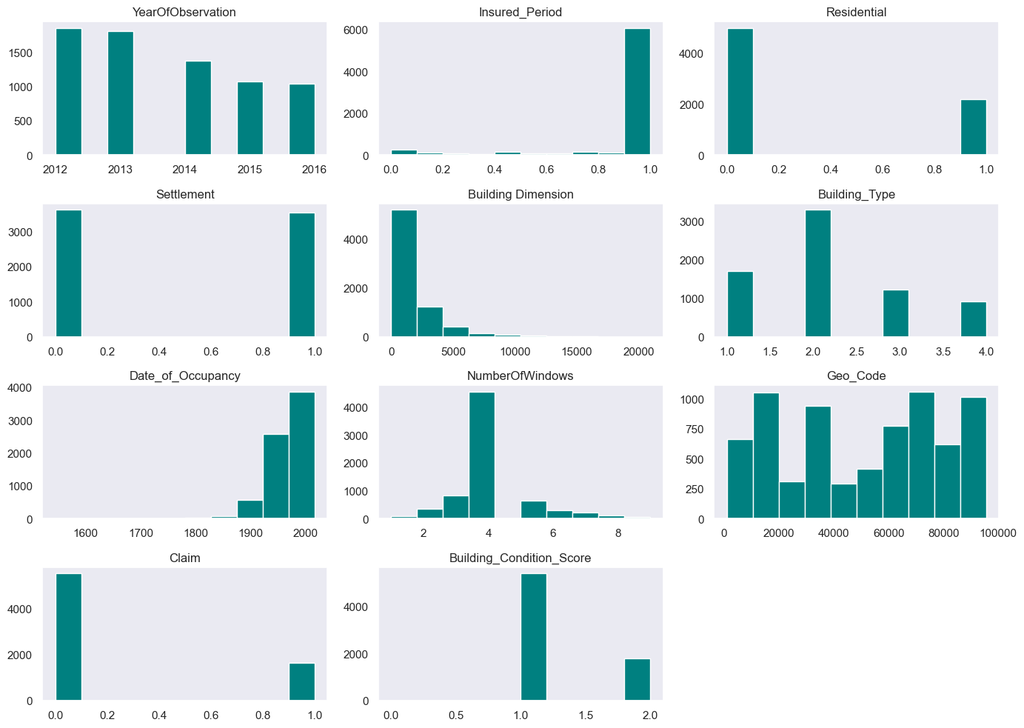

```python
df.hist(figsize=(14, 10), color='teal', edgecolor='white', grid=False)
plt.tight_layout()
plt.show()
```

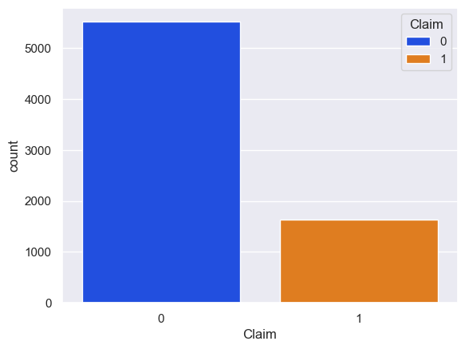

```python
sns.countplot(x='Claim', hue='Claim', palette='bright', data=df)
plt.show()
```

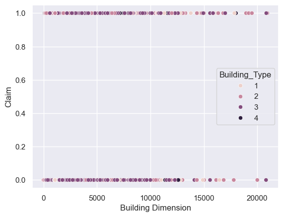

```python
sns.scatterplot(x='Building Dimension', y='Claim', hue='Building_Type', data=df)
plt.show()
```

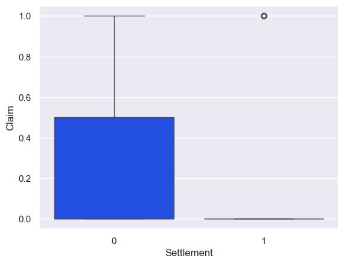

```python
sns.boxplot(x='Settlement', y='Claim',  palette='bright',
 data=df
)
plt.show()
```

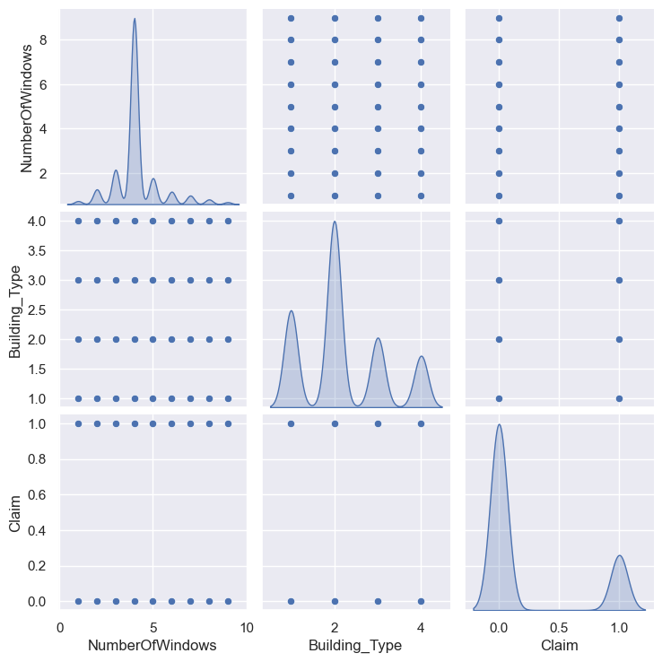

```python
sns.pairplot(
    df[['NumberOfWindows', 'Building_Type', 'Claim']],
    diag_kind='kde'
)
plt.show()
```

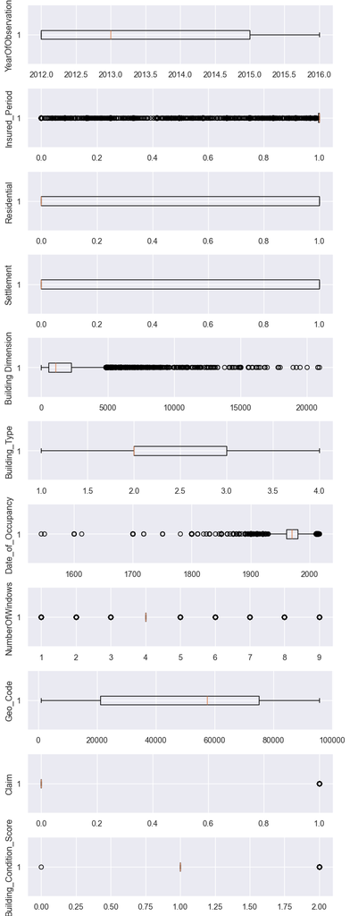

```python
fig, axs = plt.subplots(len(df.columns), 1, figsize=(7, 18), dpi=95)
for i, col in enumerate(df.columns):
    axs[i].boxplot(df[col], vert=False)
    axs[i].set_ylabel(col)
plt.tight_layout()
plt.show()
```

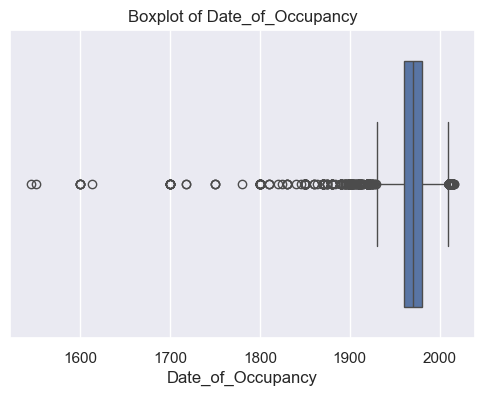

```python
import matplotlib.pyplot as plt
import seaborn as sns

plt.figure(figsize=(6, 4))
sns.boxplot(x=df['Date_of_Occupancy'])
plt.title('Boxplot of Date_of_Occupancy')
plt.show()
```

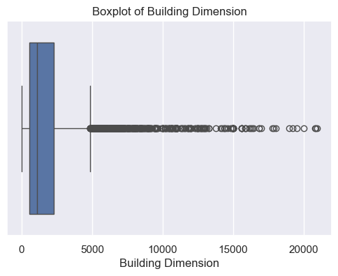

```python
plt.figure(figsize=(6, 4))
sns.boxplot(x=df['Building Dimension'])
plt.title('Boxplot of Building Dimension')
plt.show()
```

```python
Q1 = df['Building Dimension'].quantile(0.25) #calculating Q1
Q3 = df['Building Dimension'].quantile(0.75) #calculating Q3
IQR = Q3 - Q1 #calculating IQR

lower = Q1 - 1.5 * IQR #calculating lower bound
upper = Q3 + 1.5 * IQR #calculating upper bound

df['Building Dimension'] = df['Building Dimension'].clip(lower, upper) #handling outliers by capping
```

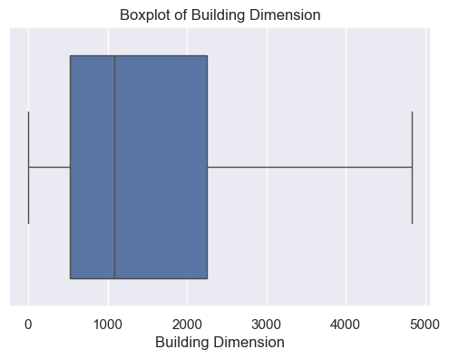

```python
import matplotlib.pyplot as plt
import seaborn as sns

plt.figure(figsize=(6, 4))
sns.boxplot(x=df['Building Dimension'])
plt.title('Boxplot of Building Dimension')
plt.show()
```

#### Categorical features were visualized using pie charts and bar plots to illustrate class proportions, while numeric Building Dimension variables were analyzed using boxplots and histograms to assess distribution and outliers.

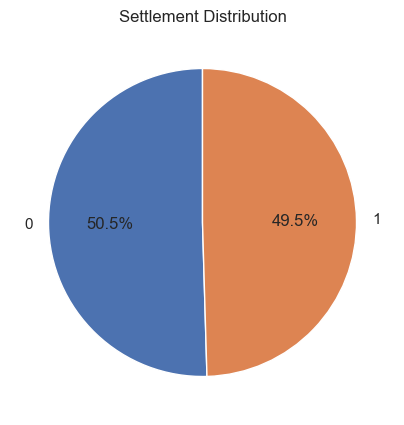

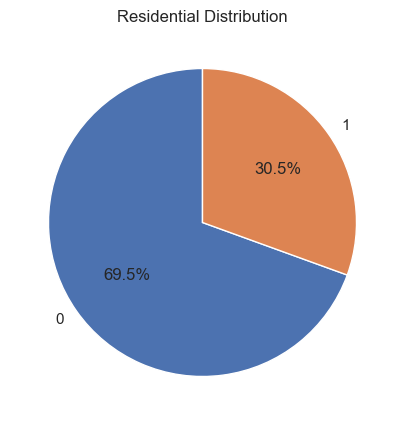

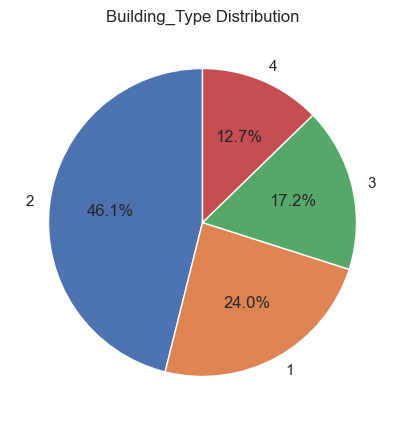

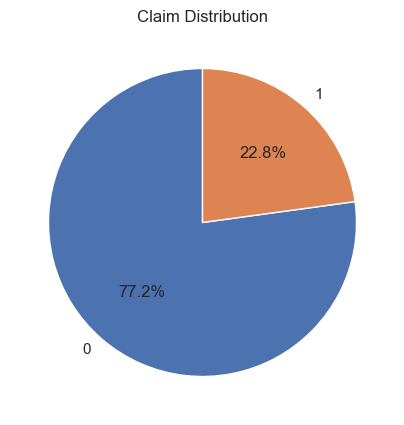

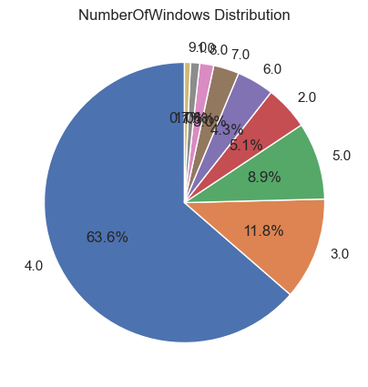

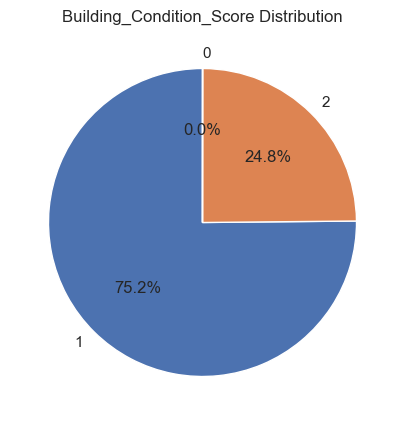

|  | YearOfObservation | Insured_Period | Residential | Settlement | Building Dimension | Building_Type | Date_of_Occupancy | NumberOfWindows | Geo_Code | Claim | Building_Condition_Score |
| --- | --- | --- | --- | --- | --- | --- | --- | --- | --- | --- | --- |
| 0 | 2013 | 1.0 | 0 | 1 | 290.0 | 1 | 1960.0 | 4.0 | 1053.0 | 0 | 2 |
| 1 | 2015 | 1.0 | 0 | 0 | 490.0 | 1 | 1850.0 | 4.0 | 1053.0 | 0 | 1 |
| 2 | 2014 | 1.0 | 0 | 1 | 595.0 | 1 | 1960.0 | 4.0 | 1053.0 | 0 | 2 |
| 3 | 2013 | 1.0 | 0 | 1 | 2840.0 | 1 | 1960.0 | 4.0 | 1053.0 | 0 | 1 |
| 4 | 2014 | 1.0 | 0 | 0 | 680.0 | 1 | 1800.0 | 3.0 | 1053.0 | 0 | 1 |

```python
cat_cols = df.select_dtypes(include=['object', 'category', 'int64']).columns #selecting categorical columns
binary_cols = [
   'Settlement',
   'Residential',
   'Building_Type',
    'Claim',
    'NumberOfWindows',
    'Building_Condition_Score'
]
#plotting pie charts for binary categorical columns
for col in binary_cols:
    counts = df[col].value_counts()

    plt.figure(figsize=(5, 5))
    plt.pie(
        counts,
        labels=counts.index,
        autopct='%1.1f%%',
        startangle=90
    )
    plt.title(f'{col} Distribution')
    plt.show() #displaying the pie chart
df.head()
```

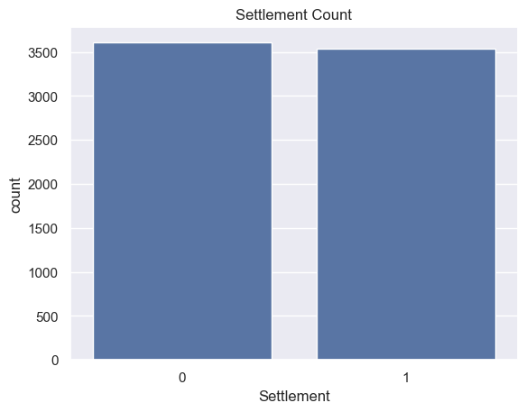

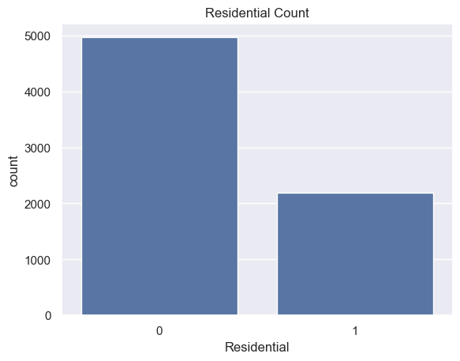

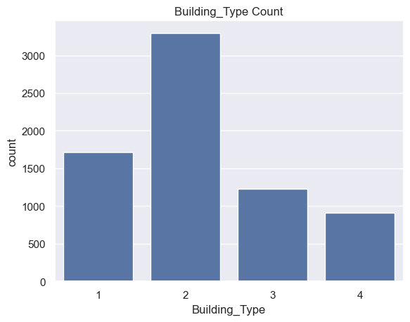

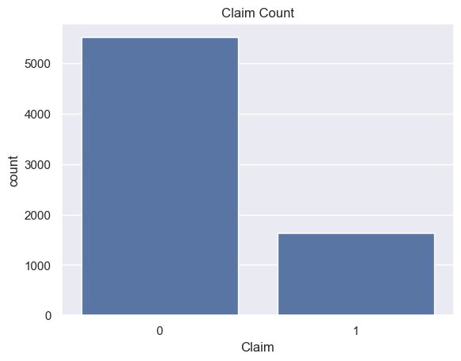

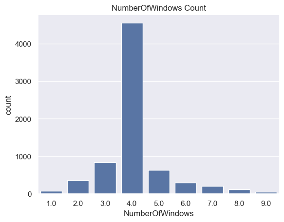

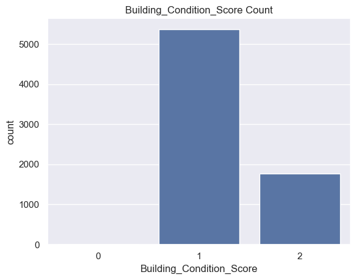

|  | YearOfObservation | Insured_Period | Residential | Settlement | Building Dimension | Building_Type | Date_of_Occupancy | NumberOfWindows | Geo_Code | Claim | Building_Condition_Score |
| --- | --- | --- | --- | --- | --- | --- | --- | --- | --- | --- | --- |
| 0 | 2013 | 1.0 | 0 | 1 | 290.0 | 1 | 1960.0 | 4.0 | 1053.0 | 0 | 2 |
| 1 | 2015 | 1.0 | 0 | 0 | 490.0 | 1 | 1850.0 | 4.0 | 1053.0 | 0 | 1 |
| 2 | 2014 | 1.0 | 0 | 1 | 595.0 | 1 | 1960.0 | 4.0 | 1053.0 | 0 | 2 |
| 3 | 2013 | 1.0 | 0 | 1 | 2840.0 | 1 | 1960.0 | 4.0 | 1053.0 | 0 | 1 |
| 4 | 2014 | 1.0 | 0 | 0 | 680.0 | 1 | 1800.0 | 3.0 | 1053.0 | 0 | 1 |

```python
for col in binary_cols:
    sns.countplot(x=col, data=df)
    plt.title(f'{col} Count')
    plt.show()
#displaying the count plot
df.head()
```

# Building the machine learning model

### 1. Features Selection

```python
selected_features = [
    'Insured_Period',
    'Residential',
    'Settlement',
    'Building Dimension',
    'Building_Type',
    'NumberOfWindows',
    'Building_Condition_Score'
] #selected features for the model

X = df[selected_features]
y = df['Claim']
```

### 2. Train–Test Split

```python
from sklearn.model_selection import train_test_split

X_train, X_test, y_train, y_test = train_test_split(
    X, y,
    test_size=0.2,
    stratify=y,
    random_state=42
)
```

```python
from sklearn.linear_model import LogisticRegression

lr = LogisticRegression(
    class_weight='balanced',
    max_iter=1000
)

lr.fit(X_train, y_train)
# decision tree
from sklearn.tree import DecisionTreeClassifier

dt = DecisionTreeClassifier(
    max_depth=5,
    class_weight='balanced',
    random_state=42
)

dt.fit(X_train, y_train)

#Random Forest Classifier
from sklearn.ensemble import RandomForestClassifier

rf = RandomForestClassifier(
    n_estimators=200,
    class_weight='balanced',
    random_state=42
)

rf.fit(X_train, y_train)

#Gradient Boosting Classifier
from sklearn.ensemble import GradientBoostingClassifier

gb = GradientBoostingClassifier(random_state=42)

gb.fit(X_train, y_train)


from sklearn.preprocessing import StandardScaler
```

### 3. Handling class imbalance

```python
from sklearn.metrics import classification_report, roc_auc_score

def evaluate_model(model, X_test, y_test):
    y_pred = model.predict(X_test)
    y_prob = model.predict_proba(X_test)[:, 1]

    report = classification_report(y_test, y_pred, output_dict=True)
    auc = roc_auc_score(y_test, y_prob)

    return {
        'Precision': report['1']['precision'],
        'Recall': report['1']['recall'],
        'F1-score': report['1']['f1-score'],
        'ROC-AUC': auc
    }
```

```python
results = {}

results['Logistic Regression'] = evaluate_model(lr, X_test, y_test)
results['Decision Tree'] = evaluate_model(dt, X_test, y_test)
results['Random Forest'] = evaluate_model(rf, X_test, y_test)
results['Gradient Boosting'] = evaluate_model(gb, X_test, y_test)
```

```python
import pandas as pd

results_df = pd.DataFrame(results).T
results_df
```

|  | Precision | Recall | F1-score | ROC-AUC |
| --- | --- | --- | --- | --- |
| Logistic Regression | 0.395699 | 0.564417 | 0.465234 | 0.693107 |
| Decision Tree | 0.393564 | 0.487730 | 0.435616 | 0.671883 |
| Random Forest | 0.366154 | 0.365031 | 0.365591 | 0.629662 |
| Gradient Boosting | 0.536913 | 0.245399 | 0.336842 | 0.694135 |

```python
y_prob = lr.predict_proba(X_test)[:, 1]

# try lower threshold to improve recall
y_pred_tuned = (y_prob >= 0.35).astype(int)
```

```python
from sklearn.metrics import classification_report

print(classification_report(y_test, y_pred_tuned))
```

```
              precision    recall  f1-score   support

           0       0.87      0.35      0.50      1104
           1       0.27      0.82      0.41       326

    accuracy                           0.46      1430
   macro avg       0.57      0.58      0.45      1430
weighted avg       0.73      0.46      0.48      1430
```

```python
from sklearn.model_selection import GridSearchCV

param_grid = {
    'C': [0.01, 0.1, 1, 10],
    'penalty': ['l1', 'l2'],
    'solver': ['liblinear']
}

grid = GridSearchCV(
    LogisticRegression(class_weight='balanced', max_iter=1000),
    param_grid,
    scoring='f1',
    cv=5
)

grid.fit(X_train, y_train)

best_lr = grid.best_estimator_
```

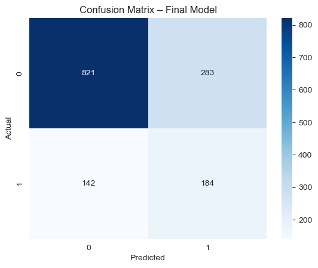

```python
from sklearn.metrics import confusion_matrix
import seaborn as sns
import matplotlib.pyplot as plt

cm = confusion_matrix(y_test, best_lr.predict(X_test))

sns.heatmap(cm, annot=True, fmt='d', cmap='Blues')
plt.xlabel('Predicted')
plt.ylabel('Actual')
plt.title('Confusion Matrix – Final Model')
plt.show()
```

```python
from sklearn.metrics import confusion_matrix

cm = confusion_matrix(y_test, best_lr.predict(X_test))
cm
```

```
array([[821, 283],
       [142, 184]])
```

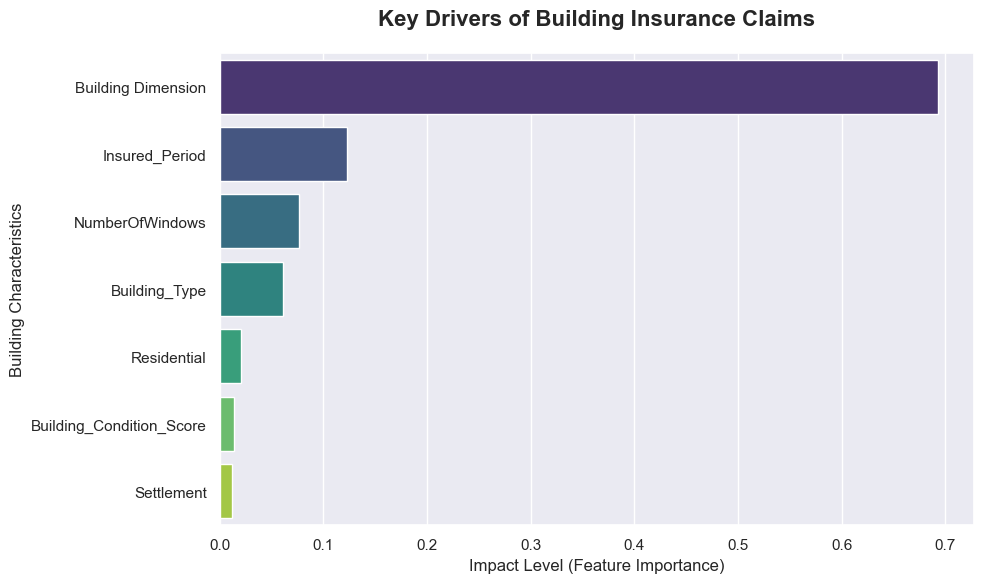

```python
import pandas as pd
import matplotlib.pyplot as plt
import seaborn as sns
from sklearn.ensemble import RandomForestClassifier # Replace with your chosen model

# 1. Prepare your data (Replace 'X' and 'y' with your variables)
# If you used a different model (like XGBoost or Logistic Regression),
# make sure to call the correct attribute for feature importance.

# Example assuming a Random Forest model named 'best_model'
importances = rf.feature_importances_
feature_names = X.columns

# 2. Create a DataFrame for the plot
feature_importance_df = pd.DataFrame({
    'Feature': feature_names,
    'Importance': importances
}).sort_values(by='Importance', ascending=False)

# 3. Create the Visualization
sns.set_theme(style="darkgrid")
plt.figure(figsize=(10, 6))

# Choose a professional color palette like 'viridis' or 'Blues_r'
plot = sns.barplot(
    x='Importance',
    y='Feature',
    data=feature_importance_df.head(10), # Show top 10 features
    palette='viridis'
)

# 4. Add Professional Styling
plt.title('Key Drivers of Building Insurance Claims', fontsize=16, fontweight='bold', pad=20)
plt.xlabel('Impact Level (Feature Importance)', fontsize=12)
plt.ylabel('Building Characteristics', fontsize=12)
plt.tight_layout()

plt.show()
```